# Evaluating Argentina’s performance in the 2022 FIFA World Cup

### Evidence

#### The Data

- With a total of 64 matches, 30 matches were looked at being the games Argentina played and also the opponents of Argentina and the games in which they played
- Six variables were taken into consideration including:
  - Possession of opponent team
  - Goals conceded of opponent team team
  - Goals scored of opponent team
  - Total Shots on target of opponent team
  - Total shots inside the penalty box of opponent team
  - Total shots outside the penalty box of opponent team
- Teams that didn’t play against Argentina weren’t included (e.g. Portugal)

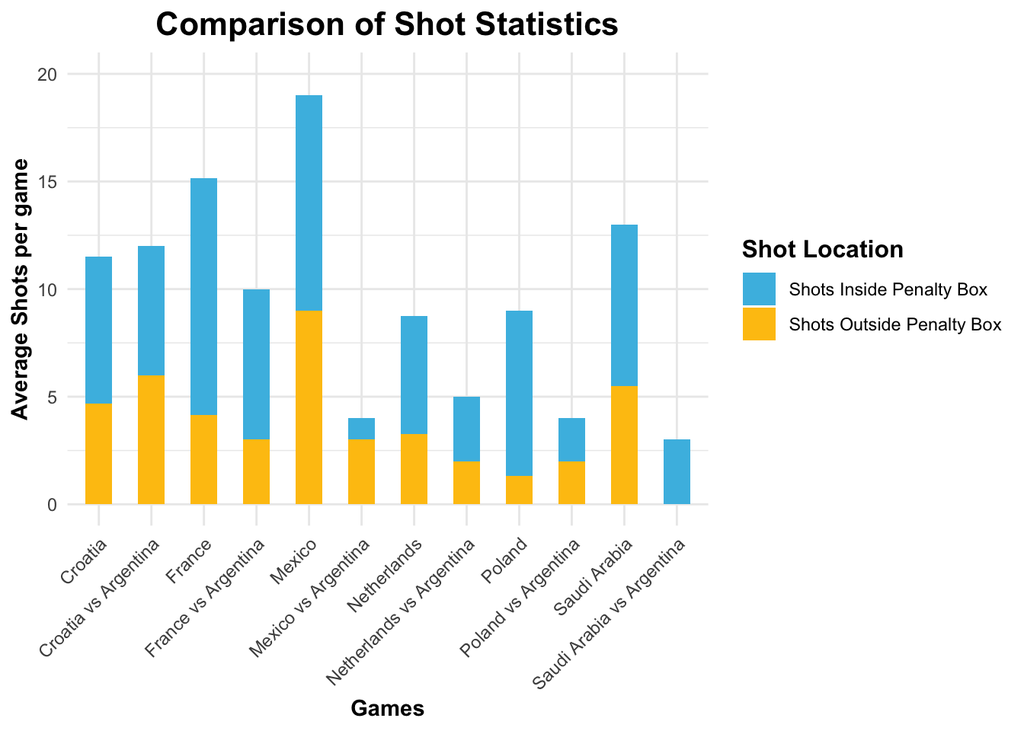

### Analysis

**Comparison of Performance Statistics: Argentina’s Opponents in Matches Against Argentina and Other Matches**

| Games (# games played) | Mean Possession | Mean Goals Conceded | Mean Goals scored |
| --- | --- | --- | --- |
| Saudi Arabia (2) | 43% | 2 goals per game | 0.5 goals per game |
| Saudi Arabia vs Argentina | 24% | 1 goal | 2 goals |
| Mexico (2) | 54.5% | 0.5 goals per game | 1 goal per game |
| Mexico vs Argentina | 36% | 2 goals | 0 goals |
| Poland (3) | 34.33% | 1.67 goals per game | 1 goal |
| Poland vs Argentina | 24% | 2 goals | 0 goals. |
| Netherlands (4) | 45% | 0.5 goals per game | 2 goals per game |
| Netherlands vs Argentina | 45% | 2 goals | 2 goals |
| Croatia (6) | 47% | 0.67 goals per game | 1.33 goals per game |
| Croatia vs Argentina | 54% | 3 goals | 0 goals scored |
| France (6) | 45.67% | 0.83 goals per game | 2.17 goals per game |
| France vs Argentina | 40% | 3 goals | 3 goals |

### Acknowledgements

ESPN Press Room. (n.d.) *Alejandro Moreno.* https://espnpressroom.com/us/bios/alejandro-moreno/

Table Magic (n.d.) *Steve Cat.* https://stevecat.net/table-magic/

Introduction to R Markdown. (2014, July 16.) *Garrett Grolemund.* https://rmarkdown.rstudio.com/articles_intro.html#

Keep rows that match a condition. (n.d.) *Hadley Wickham.* https://dplyr.tidyverse.org/reference/filter.html

How to Evaluate a Soccer Team’s Play After Every Soccer Game, Evaluate Your Team’s Performance. (n.d.) *David.* https://www.soccerhelp.com/Evaluating.shtml

### Appendix: Defense of Approach

##### Client

- Soccer analysts use data to gain insights, enhance understanding, and make informed decisions about various aspects of the game hence this choice made sense for data about the 2022 FIFA World Cup
- To accommodate to the interests of soccer analysts, a data analysis focused on the performance of World Cup winners was considered, as it is a commonly examined topic in the sport of soccer

#### Statistical Analysis

- By comparing Argentina’s performance against their opponents to the opponents’ performance in other games, the analysis highlights Argentina’s dominance and superiority throughout the tournament
- The stats of possession, goals scored, shot attempts, and goals conceded emphasize Argentina’s superior performance and their ability to outperform their opponents in key areas of the game
- In the context of analyzing Argentina’s performance, the choice to use the mean instead of the median or standard deviation was more valuable as it would better demonstrate Argentina’s performance in those categories

##### Limitations

- Doesn’t include all teams in the World Cup as it was done to ensure the data would look at the affect Argentina had on opponents they had versed
- The sample of games in which Argentina played against these opponents consists of only a single match